# Financing Decisions

## Managerial Accounting: Financing Decision

Marcelo Ortiz M.  
Fall

UPF · Barcelona School of Management

## Financing Decisions

1. Financing liabilities
2. Leases
3. Contingent liabilities and commitments
4. Off-balance-sheet financing
5. Equity financing

## 1. Financing liabilities

### Types of Liabilities

Our analysis starts distinguishing between two types of liabilities:

1. Financing liabilities: all forms of credit financing, such as bank loans, bonds, and leases.
2. Operating liabilities: obligations that arise from normal business operations, such as accounts payable, leases, accrued expenses, and taxes payable.

Of course, by traditional reporting purposes, liabilities are also classified as current or noncurrent, based on whether the obligation is expected to be satisfied within one year or the operating cycle, whichever is longer.

Let's start by focusing on financing liabilities.

[figure not shown]

[figure not shown]

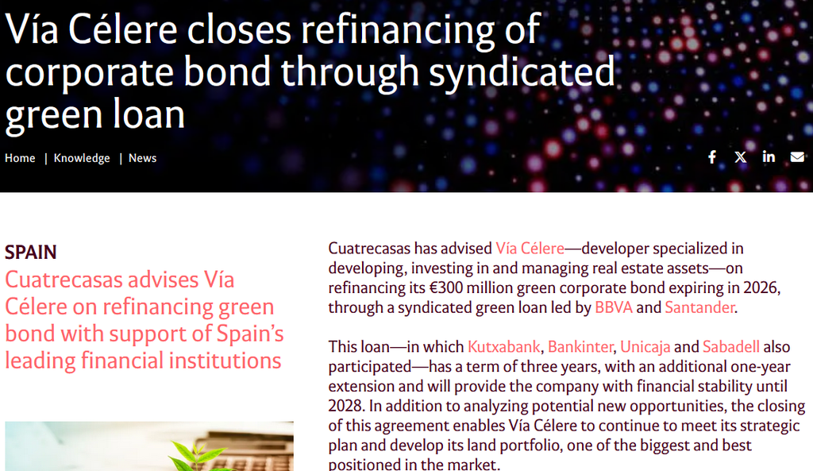

### The impact of liabilities decisions

**Note**

Exercice in MS Excel.

What is the impact on the financial statments of the following decisions? Consider that each decision is executed in January 1st and financial reporting is done at December 31st.

**Part 1**: Borrowing $1,000,000 from a bank at 5% interest rate. Interest payments are due annually at January 1st, and the principal is due in 5 years.

**Part 2**:

1. Paying off the original loan in the 5th year.
2. Refinancing the previous loan but with a 10% interest rate (principal is not paid, debt restructure)

Compare a and b regarding their impact on liquidity (current and cash ratio), solvency (debt to assets), profitability (net profit ratio) during the transition from year 4 to year 5.

One could take the numbers from the financial statements and compute solvency ratios.

But a less naive approach should consider key information from:

**The Notes:**

- Interest rates, maturity dates, conversion privileges, and redemption clauses.

**The Managerial report:**

- Expectation of refinancing, debt covenants getting tight, and future financing needs.

**With this additional information we can work on different scenarios:**

- Refinancing: What would the current cost of refinancing be? Worse? Better? How much?
- Debt reduction: Does the firm have enough cash? Issuing new shares? Selling assets?

Once we have a better picture of how the debt structure would look in the near future, we can include the respective adjustments in the financial statements before jumping into the ratios.

- This is especially true when the last report available is from many months ago.

### Credit Ratings

The credit rating of a bond is an external assessment of the issuer's ability to make timely payments of interest and principal.

[S&P Website](https://www.spglobal.com/ratings/en/about/understanding-credit-ratings)

**Bond valuation and credit ratings**

Therefore, it is not surprising that the credit rate is a major determinant of

1. the interest rate that the issuer must pay for selling more bonds.
2. the fair value of the issued bonds in the market.

**Let's look at the financial obligations of Apple and Mercedes [10 min]**

Links for the annual reports of [Apple](https://investor.apple.com/investor-relations/sec-filings/) and [Mercedes](https://group.mercedes-benz.com/investors/reports-news/annual-reports/2025/).

1. From the Balance Sheet, check the total amount on financial liabilities.
2. From the Notes, collect the following information: type of instruments, maturities, interest rates, ranking/seniority, redemption, and covenants.
   - Apple: Check Note "Debt".
   - Mercedes: Check "Combined Management Report>Refinancing", and Notes "Management of financial risks" (liquidity runoff), "Financing liabilities".

To Discuss:

- How is the debt distributed across maturities and amounts?
- What are the interest rates in these debt contracts? [How is the market now?](https://markets.businessinsider.com/bonds)
- Is any big maturity coming up soon? News from rolling over?
- **Highly Recommended**: after finding the information and concluding, prompt an AI model the same questions.

## 2. Leases

Now we move into operating liabilities ground.

**Definitions and key elements**

- A lease is a contractual agreement between a **lessor** (owner) and a **lessee** (user) that gives the lessee the right to use an asset owned by the lessor for a specified period of time in exchange for periodic payments.

### Contracting terms:

- **Minimum lease payments** (MLP), or Based Rent, are the fixed payments that the lessee is obligated to make over the lease term.
- **Contingent rentals** are payments that depend on the future performance of the leased asset.
  - Mileage for a car lease, sales performance for a retail store lease, etc.
- **Residual value guarantees** are guarantees that the lessee will pay the lessor a specified amount at the end of the lease term if the residual value of the leased asset is less than the guaranteed amount.

### Capital vs. Operating Leases:

A. Finance Lease (formerly "Capital Lease"): the arrangement is economically close to buying the asset with financing.

- It usually covers most of the asset’s useful life or value.
- the lessee effectively bears the risks and benefits of ownership.
- often with a likely ownership transfer or attractive purchase option.

*Recognition*: Lessee records a right-of-use **asset** and a lease **liability** on the balance sheet, representing the leased asset and corresponding obligation to make lease payments.

2. Operating Lease: arrangements that do not meet the criteria for capital leases.

*Recognition:* Only rental expenses are recognized, with **no impact on the balance sheet**. However, IFRS 16 (2019): Operating leases have the same accounting treatment than Capital Leases. Local Accounting Standards keep the old standard for SMEs.

An illustrative example of the impact on the financial statements of capital vs. operating leases:

- A company leases an asset on January 1, 2005.
- The company has no other assets or liabilities.
- The estimated economic life of the leased asset is 5 years and no residual value is expected.
- The lease has a fixed noncancelable term of 5 years with MLP of $2,505 per year, payable at the end of each year.

Capital lease scenario:

- The interest rate on the lease is 8% per year.
- Depreciation is computed using the straight-line method.

**Capital lease treatment**:

First, let's compute the present value of the MLP.

Remember that the PV of an annuity is given by $P_0=\frac{1-1/(1+i)^n}{i}$. In this case, $i=8\%$ and $n=5$.

- $P_0=\frac{1-1/(1.08)^5}{0.08}=3.9927$
- Leased asset value = $\$2.505\times 3.9927=10.000$

Second, compute the interest expense and depreciation expense for each year.

- notice that the interest expense is computed on the lease liability, which is updated yearly after the payment of the MLP.

| Year | Op. Lease (Rental exp.) | Interest exp. | Dep. exp. | Cap. Lease |
| --- | --- | --- | --- | --- |
| 2005 | $2,505 | $800 | $2,000 | $2,800 |
| 2006 | 2,505 | 664 | 2,000 | 2,664 |
| 2007 | 2,505 | 517 | 2,000 | 2,517 |
| 2008 | 2,505 | 358 | 2,000 | 2,358 |
| 2009 | 2,505 | 186 | 2,000 | 2,186 |
| Total | 12,525 | 2,525 | 10,000 | 12,525 |

Total expense is identical for both cases, but the timing is different: capital lease reports more expenses earlier.

But more importantly: the operating lease does not report any liability (nor asset) in the balance sheet.

However, lesses that already adopted IFRS 16 (2019) must capitalize most of the leases.

- recognition of the *right-of-use asset* and lease liability.
- leases that were previously classified as operating leases must be brought on the balance sheet.
- expense recognition: depreciation of the ROU asset ("Operating expense") and interest expense ("Financial expenses") on the lease liability.

The lessor’s accounting remains largely unchanged.

**Example Apple and Mercedes [10 min]**

Apple: Note - Leases.

Mercedes: Notes - "Lease" "Equipment in operating leases"

1. Identify the type of assets being leased.
2. Identify where the lease asset and the lease liability are reported.
3. Identify the lease maturity schedule.

## 3. Commitments and contingent liabilities

### Contingent liabilities

A contingent liability is either a possible obligation that depends on an uncertain future event or a present obligation that does not qualify for recognition (e.g., a company is under investigation for an alleged environmental violation).

**A Provision is recognized only when:**

1. Present Obligation: The obligation results from a past event.
2. Probable Outflow: It is probable that the company will have to pay.
3. Reliable Estimation: The amount can be reasonably estimated.

**Reporting:**

1. If all three conditions are met, the liability is recognized as a *Provision* in the balance sheet.
2. If the obligation is possible, or a present obligation does not meet the recognition criteria, disclosure without recognition may be required --> *Contingent Liability*.

**Example:**

A company is being sued for damages amounting to $5 million.

The company believes it is probable that it will lose the lawsuit.

It estimates the damages at $2 million (based on available evidence or legal counsel's advice).

Under IFRS, the company will recognize a *Provision* (e.g., a liability) of $2 million on the balance sheet and an *Expense* in the income statement.

**Note**

What are the managerial incentives to disclose this provision?

Why can be detrimental for shareholders to disclose of this provision?

### Commitments

A commitment is a non-cancelable promise to spend cash or take action in the future.

At the reporting date, the company has not yet received the asset or service. Therefore, it usually has no recognized liability.

Key question: Has the company already received the asset or provided a method of payment?

- No: commitment (off-balance-sheet item)
- Yes: recognize an asset, expense, or payable as appropriate.

Examples:

- Signing a Contract to purchase a machine that has not yet been delivered.
- Signing a Non-cancelable agreement to purchase minimum quantities from a supplier next year.
- Signing Licensing agreement for a future access period that has not yet begun.

| Item | Present obligation? | In balance sheet? | Typical treatment |
| --- | --- | --- | --- |
| Provision | Yes | Yes | Recognition: Estimated liability and expense |
| Contingent liability | Possible or not recognition-qualified | No | Note disclosure, unless remote |
| Commitment | Not fully yet | No | Often note disclosure only |

**Example Apple and Mercedes [15 min]**

Search: Balance sheet "Commitments and Contingencies."

Apple: Note - "Commitments ..." " and "Item 3: legal proceedings".

Mercedes: Notes - "Provisions for other risks", " Legal Proceedings", "Contingent Liabilities"

1. What type of commitments the company has? (Apple: UPO!!)
2. What type of contingent liability the company has?
   - What do they report about legal contingencies (litigation)? cases? amounts? provisions?

Once you have the information, prompt an AI model to summarize the information and complement it with your findings.

## 4. Other Off-balance-sheet financing

It refers to the non-recognition of financing activities in the financial statements.

- Operating leases were the most common example before IFRS 16.
- Other cases: special purpose entities, joint ventures, limited partnerships, etc.

### 4.1 Joint Ventures

A joint venture is a business entity created by two or more parties that pool resources and shared ownership.

Objectives:

- Resource sharing
- Market entry and expansion
- Risk mitigation
- Access to new technologies
- **Financing structuring**

Typical financing strategy:

JVs are use to avoid recognizing liabilities on the parent company's balance sheet.

- Non-consolidation: When the parent company holds less than 50% of the JV' shares with voting rights (or lacks control per IFRS 10), the JV’s assets and liabilities are not consolidated into the parent company’s financial statements. This keeps debt associated with the JV off the balance sheet of the parent company.
- Leaseback arrangements: A common tactic is for the JV to purchase assets financed by its own debt and lease/rent them back to the parent company. The parent gets to use the assets while keeping the debt off its balance sheet.

### 4.2 Special Purpose Entities (SPEs)

A special purpose entity (SPE) is a legal entity created to fulfill narrow, specific, or temporary objectives.

- Typically used by companies to isolate the firm from a specific financial risk. Example, securitization of receivables and trade-credit risk.

The typical structure of an SPE:

1. The company, called the *sponsor*, forms a separate entity and capitalizes it with equity investment, some of which must be from independent third parties.
   - again, the sponsor does not control the SPE to avoid consolidation.
2. The SPE issues debt and uses the proceeds to purchase earnings assets from or for the sponsoring company (i.e., receivables)
3. The sponsoring company receives the cash from the transaction and removes the earnings assets from its balance sheet, without recognizing a liability.

Why SPEs are so popular?

1. They allow companies to obtain lower-cost financing.
- As SPEs are restricted to a single purpose, they are less risky than the sponsoring company.
2. They allow companies to avoid violating debt covenants.
- If structured properly, the SPE is not consolidated in the sponsoring company's financial statements.

Reporting of Joint Ventures and SPEs:

- Very limited information in the annual reports:
  - Check Apple and Mercedes Benz
- In practice, it is more common to rely on specialized business databases like [Orbis](https://www.bvdinfo.com/en-gb/) or [Capital IQ](https://www.spglobal.com/marketintelligence/en/solutions/sp-capital-iq-pro).

## 5. Equity financing

Equity refers to the owners' (shareholders') financing of a company.

Commonly viewed as reflecting the **claims of owners against the assets** of the company.

Typically, holders of equity securities are **subordinate** to creditors in the event of liquidation.

### 5.1 Components of capital stock

1. Contributed/Share Capital: The amount of money raised by a company through the issuance of shares.
   - It represents the equity investment made by shareholders in exchange for ownership rights in the company.
   - One part is assigned to the par or stated value of capital shares (*Common* and/or *Preferred Stock*).
   - The remainder is reported as *Additional Paid-In Capital* (APIC) or *Share Premium*.

Example:

- Company issues 1 million common shares at a par value of $1 each, with an issuance price of $1.5 per share.
- Total capital raised: $1.5 million, where $1 million goes to the common stock account and $500,000 to APIC.
2. Treasury stock (buybacks): The amount of capital stock repurchased by the company and kept in their own treasury.
   - Why? as an attempt to increase the share price or limiting dilution.
   - It reduces both contributed capital and total equity (*contra-equity account*).
   - Recorded at cost value.
3. Retained earnings: accumulated earnings of the company that have not been distributed to shareholders as dividends.
   - Covenants can create restrictions on the use of retained earnings (check Bond indentures and Loan agreements).
4. Other comprehensive income (OCI): unrealized gain and losses not recognized in the income statement.
   - Examples: foreign currency translation adjustments, unrealized gains/losses on available-for-sale securities, and certain pension plan adjustments.
5. Noncontrolling interest (NCI) or Minority interest: the portion of a consolidated subsidiary’s equity that is owned by shareholders other than the parent company.

Typical equity events:

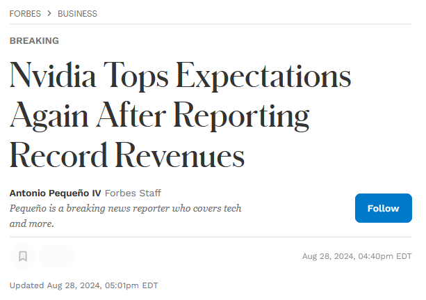

[figure not shown]

[figure not shown]

### The impact of equity decisions

**Note**

Exercice in MS Excel.

What is the impact on the financial statments of the following financing decisions? Consider that the decision is executed the last day of the fiscal year.

1. Capital Increase of $1,000,000 from the same investors base.
   - no dilution
2. Paying $300.000 in dividends.

### Classification of capital stock

1. Preferred stock
   - dividend distribution preferences (usually fixed)
   - liquidation priority
   - convertibility into common stock
   - non or limited voting rights: electing directors, approving major corporate actions,
2. Common stock
   - voting rights
   - bear the residual risk and rewards of the company

Example:

First year of operations: What is the total equity of the company?

|  | Total equity |
| --- | --- |
| **Common shares** |  |
| # shares outstanding = 100,000 |  |
| Par value = $5 | Common share capital (at par)=$500,000 |
| Issuance price = $8.5 | APIC: $350,000 |
| **Preferred shares** |  |
| # shares outstanding = 20,000 |  |
| Par value = $10 | Preferred share capital (at par)=$200,000 |
| **Net income** = $1,150,000 | Ret. earnings = $1,150,000 |
| **OCI**: $300,000 | OCI: $300,000 |
| **Dividends** = $450,000 | Dividends = -$450,000 |
| **Treasury stock** = $50,000 | Treasury stock = -$50,000 |
| **Total** | $2,000,000 |

Pay special attention to **capital stock dilution**.

Common variations in the capital stock:

- issuance of new stocks
- repurchase of stocks
- conversion of debentures and preferred stocks

Less common reasons to keep in mind:

- Stock options in executive compensation and bonus plans calling for the issuance of capital stock over some time at fixed prices (i.e., employee stock ownership plan).
- Commitments to issue capital stock in the future (i.e., stock warrants, or merger agreements).

**Questions?**

Check my website for an updated version of this presentation:

https://www.marceloortizm.com/

**Based on:**

- Subramanyam, K. R. (2014). Financial statement analysis. McGraw-Hill Education. Chapter 3.
- Steven M. Bragg (2022). IFRS Guidebook. Accounting Tools. Chapters 19 and 29.
- IFRS 16 Leases
- IAS 37 Provisions (IFRS) Contingent Liabilities and Contingent Assets
- IFRS 11 Joint Arrangements